# Visualizing FordGoBike Data

## Preliminary Wrangling

The system was originally launched as Bay Area Bike Share in August 2013. At launch, it became the first regional bicycle sharing system deployed on the West Coast of the United States and also the first regional system in the U.S. that services more than just a single city or adjacent cities. The original system was described as a pilot program and consisted of only 700 bicycles with 70 stations, 34 of which were in San Francisco. The program's original administrator was the Bay Area Air Quality Management District, which handed off the public management of the system to the Metropolitan Transportation Commission in 2016. In September 2016, Ford announced that it would sponsor the system with a contribution of $50 million, finally enabling the planned expansion from the original system's 700 bicycles to 7000. On June 28, 2017, the system officially re-launched as Ford GoBike. As of January 2018, the Bay Wheels system had about 10,000 annual subscribers, over 2,600 bicycles in 262 stations across San Francisco, East Bay and San Jose.

In June 2019, after Motivate's acquisition by Lyft, the system rebranded to Bay Wheels and dropped the Ford naming.

The bicycles are available 24 hours a day, seven days a week for periods ranging from a single ride (up to 30 minutes) to a day pass, in 30-minute increments, or customers can purchase an annual subscription which gives them unlimited rides up to 45-minutes in duration. Single rides cost $2 per trip, day passes cost $10 per day, and memberships cost $15 per month or $149 per year. A reduced pricing option called "Bike Share for All" exists for users who qualify for CalFresh, the SFMTA's Lifeline pass, or PG & E's CARE discount. The reduced price is $5 / year for the first year and $5/month in subsequent years. This membership option provides rides of 60 minutes without an additional charge. As of January 2018, around 15% of the membership of the bikeshare system used the Bike Share for All option.

I will be analyzing the 2018 dataset.

# https://en.wikipedia.org/wiki/Bay_Wheels

```python
# import all packages and set plots to be embedded inline
import numpy as np
import pandas as pd
import matplotlib.pyplot as plt
import seaborn as sb
import nbconvert as nb
import glob
import os

%matplotlib inline
```

```python
#I've saved the 12 csv files from the FordGoBike website in one location on my computer.
#Then I used glob and os modules to load, and combine the files into one new file, Ford2018.csv.
path = r'C:\Users\macie\Desktop\Ford2018'

files = glob.glob(os.path.join(path, "*.csv"))

df = pd.concat((pd.read_csv(f) for f in files), ignore_index = True)
df = pd.concat(pd.read_csv(f, skipinitialspace=True, usecols=['duration_sec', 'start_time', 'end_time',
                                                               'start_station_id', 'start_station_name',
                                                               'start_station_latitude', 'start_station_longitude',
                                                               'end_station_id', 'end_station_name', 'end_station_latitude',
                                                               'end_station_longitude', 'bike_id','user_type', 'bike_share_for_all_trip'],) for f in files)
df.to_csv('Ford2018.csv', index = False)
```

```python
# Reading in the new combined data
Ford2018 = pd.read_csv('Ford2018.csv')
```

```python
#Checking the structure
Ford2018.head(5)
```

|  | duration_sec | start_time | end_time | start_station_id | start_station_name | start_station_latitude | start_station_longitude | end_station_id | end_station_name | end_station_latitude | end_station_longitude | bike_id | user_type | bike_share_for_all_trip |
| --- | --- | --- | --- | --- | --- | --- | --- | --- | --- | --- | --- | --- | --- | --- |
| 0 | 75284 | 2018-01-31 22:52:35.2390 | 2018-02-01 19:47:19.8240 | 120.0 | Mission Dolores Park | 37.761420 | -122.426435 | 285.0 | Webster St at O'Farrell St | 37.783521 | -122.431158 | 2765 | Subscriber | No |
| 1 | 85422 | 2018-01-31 16:13:34.3510 | 2018-02-01 15:57:17.3100 | 15.0 | San Francisco Ferry Building (Harry Bridges Pl... | 37.795392 | -122.394203 | 15.0 | San Francisco Ferry Building (Harry Bridges Pl... | 37.795392 | -122.394203 | 2815 | Customer | No |
| 2 | 71576 | 2018-01-31 14:23:55.8890 | 2018-02-01 10:16:52.1160 | 304.0 | Jackson St at 5th St | 37.348759 | -121.894798 | 296.0 | 5th St at Virginia St | 37.325998 | -121.877120 | 3039 | Customer | No |
| 3 | 61076 | 2018-01-31 14:53:23.5620 | 2018-02-01 07:51:20.5000 | 75.0 | Market St at Franklin St | 37.773793 | -122.421239 | 47.0 | 4th St at Harrison St | 37.780955 | -122.399749 | 321 | Customer | No |
| 4 | 39966 | 2018-01-31 19:52:24.6670 | 2018-02-01 06:58:31.0530 | 74.0 | Laguna St at Hayes St | 37.776435 | -122.426244 | 19.0 | Post St at Kearny St | 37.788975 | -122.403452 | 617 | Subscriber | No |

```python
Ford2018.tail(5)
```

|  | duration_sec | start_time | end_time | start_station_id | start_station_name | start_station_latitude | start_station_longitude | end_station_id | end_station_name | end_station_latitude | end_station_longitude | bike_id | user_type | bike_share_for_all_trip |
| --- | --- | --- | --- | --- | --- | --- | --- | --- | --- | --- | --- | --- | --- | --- |
| 1863716 | 473 | 2018-12-01 00:11:54.8110 | 2018-12-01 00:19:48.5470 | 345.0 | Hubbell St at 16th St | 37.766474 | -122.398295 | 81.0 | Berry St at 4th St | 37.775880 | -122.393170 | 3035 | Subscriber | No |
| 1863717 | 841 | 2018-12-01 00:02:48.7260 | 2018-12-01 00:16:49.7660 | 10.0 | Washington St at Kearny St | 37.795393 | -122.404770 | 58.0 | Market St at 10th St | 37.776619 | -122.417385 | 2034 | Subscriber | No |
| 1863718 | 260 | 2018-12-01 00:05:27.6150 | 2018-12-01 00:09:47.9560 | 245.0 | Downtown Berkeley BART | 37.870139 | -122.268422 | 255.0 | Virginia St at Shattuck Ave | 37.876573 | -122.269528 | 2243 | Subscriber | No |
| 1863719 | 292 | 2018-12-01 00:03:06.5490 | 2018-12-01 00:07:59.0800 | 93.0 | 4th St at Mission Bay Blvd S | 37.770407 | -122.391198 | 126.0 | Esprit Park | 37.761634 | -122.390648 | 545 | Subscriber | No |
| 1863720 | 150 | 2018-12-01 00:03:05.7420 | 2018-12-01 00:05:36.0260 | 107.0 | 17th St at Dolores St | 37.763015 | -122.426497 | 119.0 | 18th St at Noe St | 37.761047 | -122.432642 | 4319 | Subscriber | No |

```python
#Chechikg the basic information
Ford2018.info()
```

```
<class 'pandas.core.frame.DataFrame'>
RangeIndex: 1863721 entries, 0 to 1863720
Data columns (total 14 columns):
 #   Column                   Dtype
---  ------                   -----
 0   duration_sec             int64
 1   start_time               object
 2   end_time                 object
 3   start_station_id         float64
 4   start_station_name       object
 5   start_station_latitude   float64
 6   start_station_longitude  float64
 7   end_station_id           float64
 8   end_station_name         object
 9   end_station_latitude     float64
 10  end_station_longitude    float64
 11  bike_id                  int64
 12  user_type                object
 13  bike_share_for_all_trip  object
dtypes: float64(6), int64(2), object(6)
memory usage: 156.4+ MB
```

### Define

The start_time and end_time comuns are strings instead a timedate

### Code

```python
Ford2018['start_time'] = pd.to_datetime(Ford2018['start_time'])
Ford2018['end_time'] = pd.to_datetime(Ford2018['end_time'])
```

### Test

```python
Ford2018.info()
```

```
<class 'pandas.core.frame.DataFrame'>
RangeIndex: 1863721 entries, 0 to 1863720
Data columns (total 14 columns):
 #   Column                   Dtype
---  ------                   -----
 0   duration_sec             int64
 1   start_time               datetime64[ns]
 2   end_time                 datetime64[ns]
 3   start_station_id         float64
 4   start_station_name       object
 5   start_station_latitude   float64
 6   start_station_longitude  float64
 7   end_station_id           float64
 8   end_station_name         object
 9   end_station_latitude     float64
 10  end_station_longitude    float64
 11  bike_id                  int64
 12  user_type                object
 13  bike_share_for_all_trip  object
dtypes: datetime64[ns](2), float64(6), int64(2), object(4)
memory usage: 170.6+ MB
```

### Define

The start_time and end_time comuns have all the time and date data in one colunm. we need to extract them to new columns.

### Code

```python
Ford2018['Start_date'] = [d.date() for d in Ford2018['start_time']]
Ford2018['Start_times'] = [d.time() for d in Ford2018['start_time']]
Ford2018['End_date'] = [d.date() for d in Ford2018['end_time']]
Ford2018['End_times'] = [d.time() for d in Ford2018['end_time']]
```

### Test

```python
Ford2018. info()
```

```
<class 'pandas.core.frame.DataFrame'>
RangeIndex: 1863721 entries, 0 to 1863720
Data columns (total 18 columns):
 #   Column                   Dtype
---  ------                   -----
 0   duration_sec             int64
 1   start_time               datetime64[ns]
 2   end_time                 datetime64[ns]
 3   start_station_id         float64
 4   start_station_name       object
 5   start_station_latitude   float64
 6   start_station_longitude  float64
 7   end_station_id           float64
 8   end_station_name         object
 9   end_station_latitude     float64
 10  end_station_longitude    float64
 11  bike_id                  int64
 12  user_type                object
 13  bike_share_for_all_trip  object
 14  Start_date               object
 15  Start_times              object
 16  End_date                 object
 17  End_times                object
dtypes: datetime64[ns](2), float64(6), int64(2), object(8)
memory usage: 199.1+ MB
```

### Define

The user_type and bike_share_for_all columns need to be set up as category type.

### Code

```python
Ford2018.user_type = Ford2018.user_type.astype('category')
Ford2018.bike_share_for_all_trip = Ford2018.bike_share_for_all_trip.astype('category')
```

### Test

```python
Ford2018. info()
```

```
<class 'pandas.core.frame.DataFrame'>
RangeIndex: 1863721 entries, 0 to 1863720
Data columns (total 18 columns):
 #   Column                   Dtype
---  ------                   -----
 0   duration_sec             int64
 1   start_time               datetime64[ns]
 2   end_time                 datetime64[ns]
 3   start_station_id         float64
 4   start_station_name       object
 5   start_station_latitude   float64
 6   start_station_longitude  float64
 7   end_station_id           float64
 8   end_station_name         object
 9   end_station_latitude     float64
 10  end_station_longitude    float64
 11  bike_id                  int64
 12  user_type                category
 13  bike_share_for_all_trip  category
 14  Start_date               object
 15  Start_times              object
 16  End_date                 object
 17  End_times                object
dtypes: category(2), datetime64[ns](2), float64(6), int64(2), object(6)
memory usage: 188.4+ MB
```

### Define

The duration of trips is counted in seconds it will be easyer for analysys to change this to minutes. We need to create a new column.

### Code

```python
Ford2018['duration_min'] = Ford2018['duration_sec'] / 60
```

### Test

```python
Ford2018.info()
```

```
<class 'pandas.core.frame.DataFrame'>
RangeIndex: 1863721 entries, 0 to 1863720
Data columns (total 19 columns):
 #   Column                   Dtype
---  ------                   -----
 0   duration_sec             int64
 1   start_time               datetime64[ns]
 2   end_time                 datetime64[ns]
 3   start_station_id         float64
 4   start_station_name       object
 5   start_station_latitude   float64
 6   start_station_longitude  float64
 7   end_station_id           float64
 8   end_station_name         object
 9   end_station_latitude     float64
 10  end_station_longitude    float64
 11  bike_id                  int64
 12  user_type                category
 13  bike_share_for_all_trip  category
 14  Start_date               object
 15  Start_times              object
 16  End_date                 object
 17  End_times                object
 18  duration_min             float64
dtypes: category(2), datetime64[ns](2), float64(7), int64(2), object(6)
memory usage: 202.6+ MB
```

### Define

Checking for duplicates

```python
Ford2018.duplicated().sum()
```

```
0
```

### Define

Checking for null values

### Code

```python
Ford2018.isnull().sum()
```

```
duration_sec                   0
start_time                     0
end_time                       0
start_station_id           11771
start_station_name         11771
start_station_latitude         0
start_station_longitude        0
end_station_id             11771
end_station_name           11771
end_station_latitude           0
end_station_longitude          0
bike_id                        0
user_type                      0
bike_share_for_all_trip        0
Start_date                     0
Start_times                    0
End_date                       0
End_times                      0
duration_min                   0
dtype: int64
```

```python
# Droping null values
Ford2018 = Ford2018.dropna()
```

### Test

```python
Ford2018.isnull().sum()
```

```
duration_sec               0
start_time                 0
end_time                   0
start_station_id           0
start_station_name         0
start_station_latitude     0
start_station_longitude    0
end_station_id             0
end_station_name           0
end_station_latitude       0
end_station_longitude      0
bike_id                    0
user_type                  0
bike_share_for_all_trip    0
Start_date                 0
Start_times                0
End_date                   0
End_times                  0
duration_min               0
dtype: int64
```

### Define

Extracting Month, day and hour from the start_time column. This will be needed for analysys.

```python
Ford2018['month'] = Ford2018['start_time'].dt.strftime('%B')
Ford2018['day'] = Ford2018['start_time'].dt.strftime('%a')
Ford2018['hour'] = Ford2018['start_time'].dt.hour
```

### Test

```python
Ford2018.info()
```

```
<class 'pandas.core.frame.DataFrame'>
Int64Index: 1851950 entries, 0 to 1863720
Data columns (total 22 columns):
 #   Column                   Dtype
---  ------                   -----
 0   duration_sec             int64
 1   start_time               datetime64[ns]
 2   end_time                 datetime64[ns]
 3   start_station_id         float64
 4   start_station_name       object
 5   start_station_latitude   float64
 6   start_station_longitude  float64
 7   end_station_id           float64
 8   end_station_name         object
 9   end_station_latitude     float64
 10  end_station_longitude    float64
 11  bike_id                  int64
 12  user_type                category
 13  bike_share_for_all_trip  category
 14  Start_date               object
 15  Start_times              object
 16  End_date                 object
 17  End_times                object
 18  duration_min             float64
 19  month                    object
 20  day                      object
 21  hour                     int64
dtypes: category(2), datetime64[ns](2), float64(7), int64(3), object(8)
memory usage: 243.7+ MB
```

Saving the dataset into a new file

```python
Ford2018.to_csv('Ford2018_clean.csv', index=False)
```

### What is the structure of your dataset?

The data is well organized there is little cleaning to be made, however there are some slight isiues that need to be taken care of. Before assessing the data to draw conclusions, there are some quality issues (this dataset is tidy) that need to be cleaned:

- There are missing values throughout the dataset:start_station_id, start_station_name, end_station_id, end_station_name
- Start/end times are not in the timestamp format
- The time and date are all in singe column, I need to extract them to a few differen columns
- user_type and bike_share_for_all are not a category item

This notebook uses data collected for a full 2018 year. There are more then 1'860'000 bike rides in the San Francisco Bay area. Each trip is anonymized and includes:

```
Trip Duration (seconds)
Start Time and Date
End Time and Date
Start Station ID
Start Station Name
Start Station Latitude
Start Station Longitude
End Station ID
End Station Name
End Station Latitude
End Station Longitude
Bike ID
User Type (Subscriber or Customer – “Subscriber” = Member or “Customer” = Casual)
```

### What is/are the main feature(s) of interest in your dataset?

The main features are the data related to the time when the trips take place (Hour, Day, Month). This way we can calculate when bikes are in the highes and lowes demand. There is also additional data that suggest whether te user is a subscriber or a customer.

### What features in the dataset will help support our investigation into your feature(s) of interest?

I will use heavily the start and end times, and related information. I will also make use of customer data, and try to understand why and when the users choose FordGoBike.

## Univariate Exploration

```python
# First let's check the distribution of users bike usage
users = Ford2018.user_type.value_counts()
users
```

```
Subscriber    1574991
Customer       276959
Name: user_type, dtype: int64
```

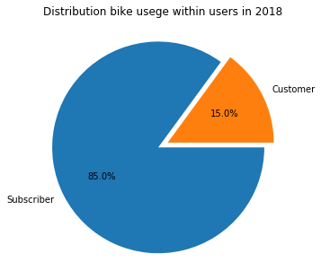

```python
plt.figure(figsize=[14,5])

plt.subplot(1, 2, 1);
sorted_vals = Ford2018.user_type.value_counts()/Ford2018.shape[0];
plt.pie(sorted_vals, explode=[0, 0.1], labels=sorted_vals.index, counterclock=False, autopct='%1.1f%%');
plt.title('Distribution bike usege within users in 2018')
plt.axis('square');
```

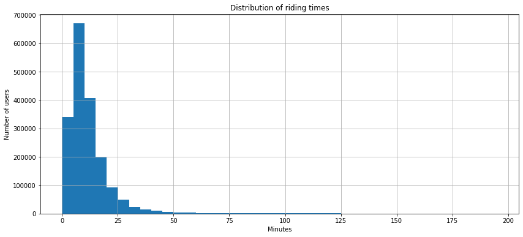

```python
# Now lest see the distribution of usage time
bin_values = np.arange(start=0, stop=200, step=5)
wn_carrier = Ford2018[Ford2018['duration_min'] == 'WN']
Ford2018['duration_min'].hist(bins=bin_values, figsize=[14,6])
plt.xlabel('Minutes');
plt.ylabel('Number of users')
plt.title('Distribution of riding times');
```

It seems that the ride usually takes about 10 minutes.

```python
# Creating the categories for day so the sorting will be correct
from pandas.api.types import CategoricalDtype
cats = ['Mon', 'Tue', 'Wed', 'Thu', 'Fri', 'Sat', 'Sun']
cat_type = CategoricalDtype(categories=cats, ordered=True)
Ford2018['day'] = Ford2018['day'].astype(cat_type)
```

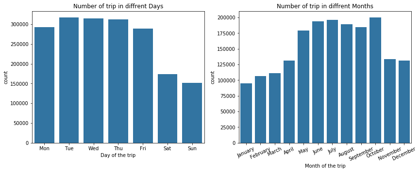

```python
# Let's see how the distribution of of bike rides looks in a week and in a year
plt.figure(figsize=[14,5])

plt.subplot(1, 2, 1)
sb.countplot(data=Ford2018, x='day', color=sb.color_palette()[0]);
plt.xlabel('Day of the trip')
plt.title('Number of trip in diffrent Days');

plt.subplot(1, 2, 2)
sb.countplot(data=Ford2018, x='month', color=sb.color_palette()[0]);
plt.xlabel('Month of the trip')
plt.title('Number of trip in diffrent Months')
plt.xticks(rotation = 25);
```

As anticipated the most popular months for bike riding are month were it is warmer (May - October). Furthermore the bikes are very heavily used on weekdays (Mon-Fri). So it seems that more people use them to travel to and from work then on a casual weekend ride.

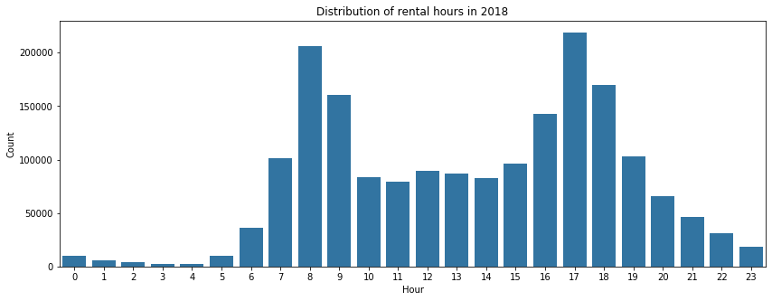

```python
# How the distribution looks like hourly

plt.figure(figsize=[14,5])
sb.countplot(data=Ford2018, x='hour', color=sb.color_palette()[0]);
plt.title('Distribution of rental hours in 2018')
plt.xlabel('Hour')
plt.ylabel('Count');
```

This observation only confirms that the FordGoBike system is used mainly to get to and from work.

```python
# Let's see are there any more popular bikes that really stand out
Ford2018.bike_id.value_counts().head(10)
```

```
3961    1220
4452    1141
3729    1062
3379    1057
3254    1055
3650    1054
3587    1053
3663    1049
4456    1046
3570    1044
Name: bike_id, dtype: int64
```

Nope.

```python
# Are there any top start and end stations?
Ford2018.start_station_name.value_counts().head(5)
```

```
San Francisco Ferry Building (Harry Bridges Plaza)           38461
San Francisco Caltrain Station 2  (Townsend St at 4th St)    37617
San Francisco Caltrain (Townsend St at 4th St)               35092
Market St at 10th St                                         34918
Berry St at 4th St                                           33716
Name: start_station_name, dtype: int64
```

```python
Ford2018.end_station_name.value_counts().head(5)
```

```
San Francisco Caltrain Station 2  (Townsend St at 4th St)    50000
San Francisco Ferry Building (Harry Bridges Plaza)           44113
San Francisco Caltrain (Townsend St at 4th St)               42970
The Embarcadero at Sansome St                                39222
Montgomery St BART Station (Market St at 2nd St)             35955
Name: end_station_name, dtype: int64
```

The most popular ride in the Bay Area is between:

### San Francisco Ferry Building (Harry Bridges Plaza)

and

### San Francisco Caltrain Station 2 (Townsend St at 4th St)

Fun fact: It tuns out that a lot of bike users are Lyft employees who come to/from work. Also the time of a ride is approx. 12 min.

[figure not shown]

```python
from IPython.display import Image
Image('Most_popular_ride_2018.png')
```

### Distribution(s) of your variable(s) of interest.

Because the creators of the oryginal dataset did a pretty good job with creating it and some small cleaning efforts I didn't encounter any surprises during the exploratory and visualization.

### Unusual distributions

Nothing seems out of the ordinary for a bike sharing system. Thus far, the data showed that the main users of this bike system are using it to get to and from work. What was supprising is that main users are Lyft employees.

## Bivariate Exploration

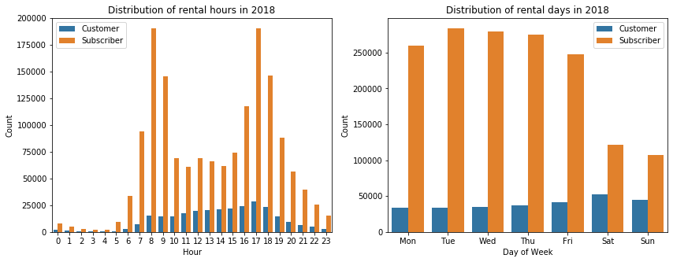

```python
# Let's take a deeper dive into hourly and mothly usage, now with Subscribers and users seperetely
plt.figure(figsize=[14,5])

plt.subplot(1, 2, 1)
sb.countplot(data=Ford2018, x='hour', hue='user_type');
plt.title('Distribution of rental hours in 2018')
plt.xlabel('Hour')
plt.ylabel('Count')
plt.legend();

plt.subplot(1, 2, 2)
sb.countplot(data=Ford2018, x='day', hue='user_type');
plt.title('Distribution of rental days in 2018')
plt.xlabel('Day of Week');
plt.ylabel('Count')
plt.legend();
```

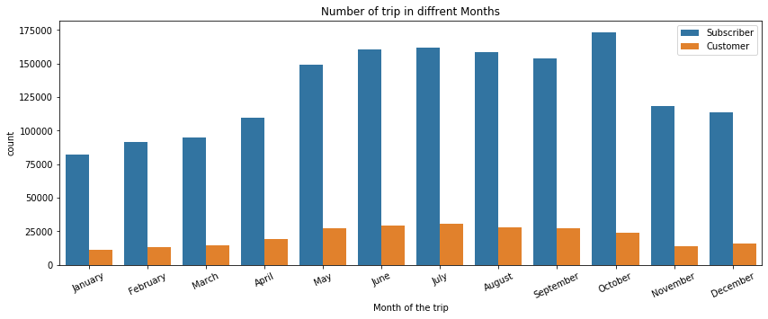

```python
# Let's see the monthly usage by user type as well
plt.figure(figsize=[14,5])

sb.countplot(data=Ford2018, x='month', hue='user_type');
plt.xlabel('Month of the trip')
plt.title('Number of trip in diffrent Months')
plt.xticks(rotation = 25)
plt.legend();
```

## This analysys shows the trends of users:

- The Subscribers use the bikes on a daily baysys, mainly between 8am and 5pm. They also use the bikes more often Monday - Friday. This can meen that they use bikes to get from and to work.
- The Customer uses the bikes slightly more often on weekends than in normal week days, and tend to use them in the afternoon (3pm-5pm).

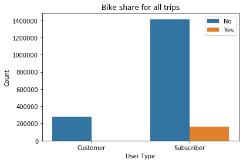

```python
# Let's check is the Bike Share for all trips is popular?
sb.countplot(data=Ford2018, x='user_type', hue='bike_share_for_all_trip');
plt.xlabel('User Type');
plt.ylabel('Count')
plt.title('Bike share for all trips')
plt.legend();
```

Wery little Subscribers use this possibility. None of the Customers do.

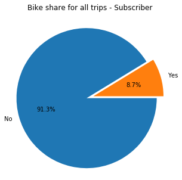

```python
# Let's check how the distribution with the Subscribers looks like
plt.figure(figsize=[10,5])
sorted_vals = Ford2018.bike_share_for_all_trip.value_counts()/Ford2018.user_type.value_counts('Subscriber')[0];
plt.pie(sorted_vals, explode=[0, 0.1], labels=sorted_vals.index, counterclock=False, autopct='%1.1f%%');
plt.title('Bike share for all trips - Subscriber')
plt.axis('square');
```

Turns out only 8,7% Subscribers use this possibility. So we can say that this isn't a very popular service.

```python
# The same but with a violin plot
Ford2018 = Ford2018.query('duration_min <= 60')
```

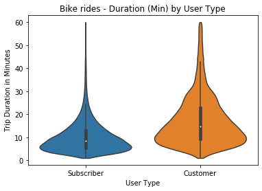

```python
sb.violinplot(data=Ford2018,
              x='user_type', y='duration_min', cut=0, scale='width', height=4)
plt.xlabel('User Type');
plt.ylabel('Trip Duration in Minutes')
plt.title('Bike rides - Duration (Min) by User Type');
```

We can observe that Customers tend to have longer bike rides then Subscribers.

### Other features (not the main feature(s) of interest).

The Bike Share For All system isn't very popular. Customers trips are usually little longer than that of Subscribers, I think that this is because they prefer bike rides on weekends and sligtly in the summer.

## Multivariate Exploration

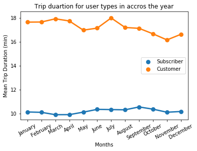

```python
# Now let's check the trip durration of user types
sb.pointplot(data = Ford2018, x = 'month', y = 'duration_min', hue = 'user_type', ci=None)
plt.title('Trip duartion for user types in accros the year')
plt.ylabel('Mean Trip Duration (min)')
plt.xlabel('Months')
plt.xticks(rotation = 28)
plt.legend()
plt.show();
```

```python
# I wan't to calculate the distance covered between stations from latitude and longitude
# https://stackoverflow.com/questions/19412462/getting-distance-between-two-points-based-on-latitude-longitude
from math import sin, cos, sqrt, atan2, radians

def distance (lat1,lon1,lat2,lon2):
    R = 6371

    lat1 = radians(lat1)
    lon1 = radians(lon1)
    lat2 = radians(lat2)
    lon2 = radians(lon2)

    dlon = lon2 - lon1
    dlat = lat2 - lat1

    a = sin(dlat / 2)**2 + cos(lat1) * cos(lat2) * sin(dlon / 2)**2
    c = 2 * atan2(sqrt(a), sqrt(1 - a))

    distance = R * c
    return np.float64(distance)
```

```python
Ford2018['distance_km'] = Ford2018.apply(lambda row: distance(row['start_station_latitude'],row['start_station_longitude'],row['end_station_latitude'],row['end_station_longitude']),axis=1)
```

```python
Ford2018.sample(5)
```

|  | duration_sec | start_time | end_time | start_station_id | start_station_name | start_station_latitude | start_station_longitude | end_station_id | end_station_name | end_station_latitude | ... | bike_share_for_all_trip | Start_date | Start_times | End_date | End_times | duration_min | month | day | hour | distance_km |
| --- | --- | --- | --- | --- | --- | --- | --- | --- | --- | --- | --- | --- | --- | --- | --- | --- | --- | --- | --- | --- | --- |
| 616300 | 171 | 2018-05-02 07:02:01.488 | 2018-05-02 07:04:53.454 | 126.0 | Esprit Park | 37.761634 | -122.390648 | 130.0 | 22nd St Caltrain Station | 37.757369 | ... | No | 2018-05-02 | 07:02:01.488000 | 2018-05-02 | 07:04:53.454000 | 2.850000 | May | Wed | 7 | 0.490186 |
| 552549 | 350 | 2018-05-12 18:47:24.996 | 2018-05-12 18:53:15.597 | 256.0 | Hearst Ave at Euclid Ave | 37.875112 | -122.260553 | 240.0 | Haste St at Telegraph Ave | 37.866043 | ... | Yes | 2018-05-12 | 18:47:24.996000 | 2018-05-12 | 18:53:15.597000 | 5.833333 | May | Sat | 18 | 1.019999 |
| 914168 | 284 | 2018-07-17 09:20:59.098 | 2018-07-17 09:25:43.972 | 253.0 | Haste St at College Ave | 37.866418 | -122.253799 | 239.0 | Bancroft Way at Telegraph Ave | 37.868813 | ... | No | 2018-07-17 | 09:20:59.098000 | 2018-07-17 | 09:25:43.972000 | 4.733333 | July | Tue | 9 | 0.510703 |
| 1110929 | 1047 | 2018-08-15 18:30:03.352 | 2018-08-15 18:47:31.092 | 66.0 | 3rd St at Townsend St | 37.778742 | -122.392741 | 112.0 | Harrison St at 17th St | 37.763847 | ... | No | 2018-08-15 | 18:30:03.352000 | 2018-08-15 | 18:47:31.092000 | 17.450000 | August | Wed | 18 | 2.432068 |
| 1700805 | 563 | 2018-11-04 12:58:19.106 | 2018-11-04 13:07:42.233 | 107.0 | 17th St at Dolores St | 37.763015 | -122.426497 | 125.0 | 20th St at Bryant St | 37.759200 | ... | No | 2018-11-04 | 12:58:19.106000 | 2018-11-04 | 13:07:42.233000 | 9.383333 | November | Sun | 12 | 1.523530 |

5 rows × 23 columns

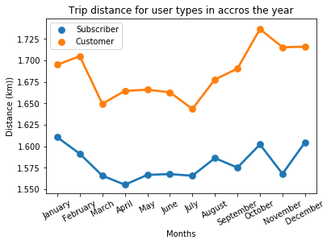

```python
# I wan't check also the distance covered by users in different months
sb.pointplot(data = Ford2018, x = 'month', y = 'distance_km', hue = 'user_type', ci=None)
plt.title('Trip distance for user types in accros the year')
plt.ylabel('Distance (km))')
plt.xlabel('Months')
plt.xticks(rotation = 28)
plt.legend()
plt.show();
```

As stated before we can see clearly that Customers take longer rides than Subscribers.

### Talk about some of the relationships you observed in this part of the investigation. Were there features that strengthened each other in terms of looking at your feature(s) of interest?

This section confirmed what we suspected from the previous data explorations. By adding additional variables to compare to like Subscriber vs Customer trip duartion and/or trip distance. As it was previously stated, Customers and Subscribers use bikes for different purposes.

### Were there any interesting or surprising interactions between features?

Not much out of the ordinary. One thing is supprising - drop of averadge km driven by Customers between March and July. But this can be an effect of calculating the trip distances. It is impossible to count the distance when the Start station and End station is the same, then we have 0km distance covered.